# Raport 3

Magdalena Wawrzyniak

## Wprowadzenie

### Użyte funkcje

W tym raporcie spora część zadań opierała się na tym samym, w związku z tym na początek utworzyłam najpotrzebniejsze funkcje, z których będę korzystać w trakcie. Zanim przejdziemy do omówienia zadań przyjrzyjmy się z czego będziemy korzystać, tak aby w dalszej części raportu już tego nie tłumaczyć tak szczegółowo. Ziarno ustawiono na 13.

Pierwsza funkcja, z której będziemy korzystać praktycznie w każdym zadaniu, to funkcja o nazwie `model`. Przyjmuje ona ramkę danych, a także numery kolumn X oraz Y, czyli zmiennych objaśniającej i objaśnianej. Na wyjściu otrzymujemy model regresji liniowej dla podanych danych.

```r
model <- function(data_for_model, nr_col_X, nr_col_Y){
  X_name <- data_for_model[, nr_col_X]
  Y_name <- data_for_model[, nr_col_Y]
  model_name <-  lm(Y_name~X_name, data_for_model)
  return(model_name)
}
```

Kolejna funkcja z jakiej będziemy korzystać, to funkcja o nazwie `summary_of_model`, która przyjmuje w argumencie model i wybiera z niego najistotniejsze dla nas informacje. Wynikiem jej działania jest krótka tabelka z podsumowaniem dla modelu.

```r
summary_of_model <- function(model_name){
   intercept <- coefficients(model_name)[1]
   slope     <- coefficients(model_name)[2]
   R2        <- summary(model_name)$r.squared
   t_value   <- summary(model_name)$coefficients[2,3]
   p_value   <- summary(model_name)$coefficients[2,4]
   sigma2    <- (summary(model_name)$sigma)^2
   F_value   <- summary(model_name)$fstatistic[1]
   score     <- c(intercept, slope, R2, t_value, p_value, sigma2, F_value)
   table_mod <- data.frame(round(score, 4))
   colnames(table_mod) <- "wyniki"
   rownames(table_mod) <- c("wyraz wolny", "wsp. kierunkowy", "R2", "wartość statystyki t ", "p-wartość", "sigma2", "wartość F")
  return(table_mod)
}
```

Następne trzy funkcje dotyczą tworzenia wykresów. Pierwsza z nich o nazwie `graph_pred` przeprowadza predykcje na podstawie wprowadzonych danych, a następnie generuje (jeżeli `typ = TRUE`) wykres z naszej próby, z zaznaczonym przedziałem predykcji oraz prostą regresji. Jeżeli zmienimy typ na `FALSE`, to zamiast wykresu otrzymamy ramkę danych z wynikami predykcji, na których później możemy jeszcze samodzielnie manipulować. Opcja ta została wprowadzona przez formę zadań 10-12, w których manipulujemy tymi wynikami, aby lepiej dopasować model. Argumenty jakie należy wprowadzić, to kolejno: ramka danych, model, numery kolumn dla X i Y, nazwy osi $x$ i $y$, no i oczywiście opcjonalnie typ.

```r
graph_pred <- function(data_for_model, model_name, nr_col_X, nr_col_Y,
                       name_xlab, name_ylab, typ = TRUE){

  X_name <- data_for_model[, nr_col_X]
  Y_name <- data_for_model[, nr_col_Y]

  prediction <- data.frame(predict(model_name,
                          newdata = data.frame(X_name = data_for_model[, nr_col_X]),
                          interval = "prediction"))
  data_graph <- cbind(data_for_model, prediction)

  graph <- ggplot(data_graph, aes(x = X_name, y = data_graph[, nr_col_Y])) +
              geom_point() +
              geom_line(aes(x = X_name, y = fit), col = "red") +
              geom_ribbon(aes(ymin = lwr, ymax = upr), alpha = 0.4) +
              xlab(name_xlab) + ylab(name_ylab)
  if (typ == TRUE){
    return(graph)
  }
  else return(data_graph)
}
```

Kolejna funkcja przyda się w zadaniu 5 i zadaniu 6, ponieważ to dzięki niej będziemy rysować wykresy dla reszt (residuów). Poza argumentem typ, pozostałe przyjmujemy takie same jak dla poprzedniej funkcji. Dodatkowo możemy jeszcze określić czy chcemy uwzględniać kolejność danych występujących w pliku, z którego wgrywamy dane (`sorting = FALSE` ozn. nie uwzględniamy).

```r
res_graph <- function(data_for_model, model_name, nr_col_X = 2, sorting = FALSE,
                      name_xlab = "liczba kopiarek", name_ylab = "residua"){
  residua    <- model_name$residuals
  n <- length(residua)
  X_name <- data_for_model[, nr_col_X]
  if (sorting == TRUE){
    X_name <- sort(X_name)
  }
  graph_data <- data.frame(X_name, residua)
  graph <- ggplot() +
              geom_point(graph_data,
                         mapping = aes(x = X_name, y = residua)) +
              geom_point(graph_data[1, ],
                         mapping = aes(x = X_name[1], y = residua[1]),
                         colour = "blue") +
              geom_line(mapping = aes(x = X_name, y = 0), colour = "red") +
              xlab(name_xlab) + ylab(name_ylab)
  return(graph)
}
```

```r
normal_dist <- function(model_name){
  residua    <- model_name$residuals
  X_name <- seq(min(residua), max(residua), by=0.1)
  d      <- dnorm(X_name)

  graph  <- ggplot() +
              geom_histogram(aes(x = residua, y = ..density..),
                             bins = 15, colour = "white") +
              geom_density(data.frame(residua), mapping = aes(x = residua), lwd = 1,
                           colour = 4, fill = 4, alpha = 0.25) +
              xlab("residua")

 return(graph)

}
```

### Wgrywanie danych

Po omówieniu funkcji przejdźmy do krótkiego opisu zadań i wgrania danych z plików.

W zadaniu 3 i 4 będziemy korzystać z danych zapisanych w pliku `tabela1_6.txt`, zawierającego średnią ocen (GPA) , wynik standardowego testu IQ, płeć oraz wynik testu psychologicznego - Piers-Harris Childrens Self - Concept Scale, dla 78 uczniów klasy siódmej.

```r
# Zad 3, 4
GPA_data <- read.table("~/Uczelnia/Semestr_5.1/Modele_liniowe/ML_Lista_3/tabela1_6.txt")
GPA_data <- GPA_data[,c(2:5)]

colnames(GPA_data) <- c("GPA","score on IQ test", "gender", "score on the P-H test")
```

W zadaniu 5 i 6 korzystamy z danych, które omawialiśmy w raporcie 2(`CH01PR20.txt`). Będziemy badać czas serwisowania kopiarek Y), w zależności od ich ilości (X). W 6 zadaniu podmieniamy czas z pierwszego wiersza, z $20$ na $2000$.

```r
# Zad 5, 6
copy_machines_1 <- read.table("CH01PR20.txt",
                            col.names = c("time", "copiers"))
copy_machines_2 <- copy_machines_1
copy_machines_2[1,1] <- 2000
```

W przypadku następnych sześciu zadań użyjemy danych z pliku `CH03PR15.txt`. W pierwszej kolumnie podane są wartości stężenia roztworu (zmienna objaśniana), a w drugiej czas (zmienna objaśniająca). W zadaniu 12 zmieniamy dane zgodnie z treścią, tak aby czas był teraz równy $czas^{-\frac{1}{2}}$.

```r
# Zad 7-12
solution_concentration  <- read.table("CH03PR15.txt",
                                      col.names = c("concentration", "time" ))
## do 10
log_solution_concentration <- solution_concentration
log_solution_concentration[, 1] <- log(log_solution_concentration$concentration)
## do 12
sqrt_solution_concentration <- solution_concentration
sqrt_solution_concentration[, 2] <- 1/sqrt(log_solution_concentration$time)
```

## Zadanie 3

### (a)

W podpunkcie pierwszym proszą nas o stworzenie morelu regresji liniowej, a następnie podanie wartości $R^2$, współczynników modelu, a także wartości statystyki testowej F i p-wartość.

```r
model_IQ   <- model(GPA_data, 2, 1)
summary_IQ <- summary_of_model(model_name = model_IQ)
summary_IQ
```

|  | wyniki |
| --- | --- |
| wyraz wolny | -3.5571 |
| wsp. kierunkowy | 0.1010 |
| R2 | 0.4016 |
| wartość statystyki t | 7.1420 |
| p-wartość | 0.0000 |
| sigma2 | 2.6725 |
| wartość F | 51.0085 |

Dostajemy równanie regresji postaci:
$$\hat{ Y } = 0.1010 X - 3.5570558$$
Na podstawie powyższych obserwacji skonstruowany jest tzw. test F testujący czy współczynnik kierunkowy jest różny od 0:

H0: Y jest niezależny od X,

H1: Y zależy od X;

Odrzucamy hipotezę zerową, gdy $F=\frac{MSM}{MSE} > F_c$, gdzie $F_c = F^∗(1−\alpha, 1, n−2)$ jest kwantylem rzędu $1−\alpha$ z rozkładu Fishera–Snedecora z $1$ i $n-2$ stopniami swobody.

Możemy policzyć to ręcznie. Statystykę testową F wyliczamy ze wzór
$$F=MSM/MSE,$$
gdzie
$$MSM=\sum^n_{i=1}(\hat{Y_i}−
mean(Y_i))^2,$$
$$MSE=\frac{\sum^n_{i=1}(Y_i−\hat{Y_i})^2}{n-2} =
s^2.$$
Zwykle, wnioskowanie dokonywane jest na podstawie p-wartości:$p=P(z>F),$ gdzie $z∼F(1, n−2)$ Tak samo możemy wyliczyć miarę dopasowania modelu, czyli
$$R^2 =
\frac{SSM}{SST}.$$
Może to wyglądać przykładowo tak ja na dole:

```r
n = 78
SSE <- sum((GPA_data$GPA - GPA_data$`score on IQ test`*0.1010+3.5571)^2)
SST <- sum((GPA_data$GPA- mean(GPA_data$GPA))^2)
SSM <- SST - SSE
dfE <- n - 2
dfM <- 1
dfT <- dfE + dfM
MSM <- SSM/dfM
MSE <- SSE/dfE
F_stat <- MSM/MSE
F_stat
```

```
## [1] 51.00817
```

```r
qf(0.95,df1=1, df2=n-2)
```

```
## [1] 3.96676
```

```r
R2 <- SSM/SST
R2
```

```
## [1] 0.4016133
```

```r
F_stat > qf(0.95,df1=1, df2=n-2)
```

```
## [1] TRUE
```

Oczywiście zamiast statystyki F możemy zastosować statystykę t, ponieważ nasz model posiada tylko jedną zmienną objaśniającą. Niezależnie od tego otrzymujemy, że hipoteze zerową należy odrzucić i przyjąć hipotezę alternatywną, że średnia ocen zależy od poziomu IQ.

### (b)

```r
predict(model_IQ,
        newdata = data.frame(X_name = 100),
        interval = "prediction",
        lerd = 0.9)
```

```
##        fit      lwr      upr
## 1 6.545114 3.258753 9.831475
```

Według modelu wartość średniej będzie należeć do przedziału pomiędzy 3.25, a 9.83, chociaż jeżeli obserwacja będzie zachowywać się zgodnie z zadanym przez nas modelem, to powinniśmy otrzymać wynik bliski 6.55.

### (c)

W podpunkcie (c) rysujemy przedział predykcyjny dla naszych danych, przy $\alpha = 0.05$.

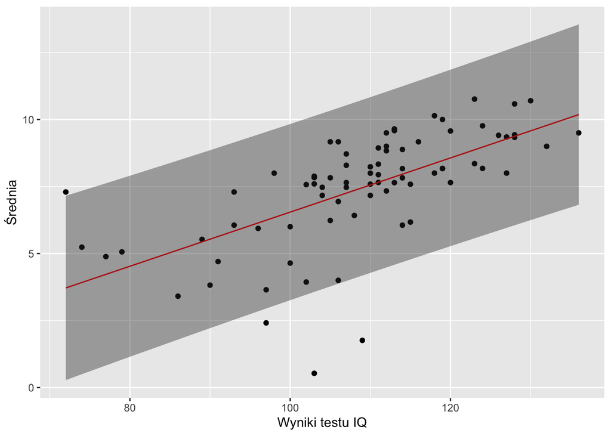

```r
graph_pred(GPA_data, model_IQ, 2, 1, "Wyniki testu IQ", "Średnia")
```

## Zadanie 4

W tym zadaniu będziemy badać zależność między średnią ocen - GPA (Y), a wynikami testu Piersa-Harrisa (X).

### (a)

W podpunkcie (a) mamy podać dopasowane równanie regresji i $R^2$.

```r
model_PH <- model(GPA_data, 4, 1)
summary_PH <- summary_of_model(model_PH)
summary_PH
```

|  | wyniki |
| --- | --- |
| wyraz wolny | 2.2259 |
| wsp. kierunkowy | 0.0917 |
| R2 | 0.2936 |
| wartość statystyki t | 5.6201 |
| p-wartość | 0.0000 |
| sigma2 | 3.1550 |
| wartość F | 31.5852 |

```r
summary_PH[7,1] > qf(0.95,df1=1, df2=n-2)
```

```
## [1] TRUE
```

Dostajemy równanie regresji postaci:
$$\hat{ Y } = 0.0917 X + 2.2259$$
Przeprowadzając test na podstawie statystyki F:

H0: Y jest niezależny od X,

H1: Y zależy od X;

dostajemy, że odrzucamy hipotezę zerową i przyjmujemy alternatywną.

### (c)

```r
predict(model_PH,
        newdata = data.frame(X_name = 60),
        interval = "prediction",
        lerd = 0.9)
```

```
##       fit      lwr      upr
## 1 7.72502 4.163398 11.28664
```

Interpretacja analogiczna jak w zadaniu 3.

### (d)

W podpunkcie (d) rysujemy przedział predykcyjny dla naszych danych, przy $\alpha = 0.05$

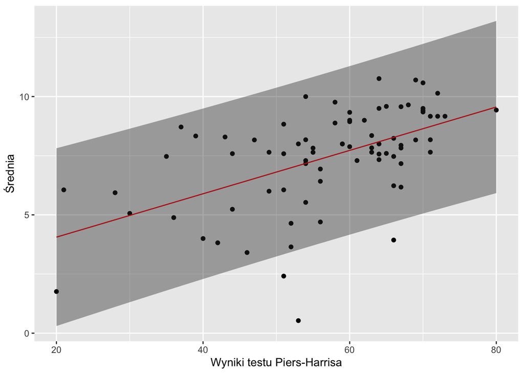

```r
graph_pred(GPA_data, model_PH, 4, 1, "Wyniki testu Piers-Harrisa", "Średnia")
```

Dla testu Piers-Harris tylko 3 wyniki wyszły poza wyznaczony przedział predykcyjny, co oczywiście jest wynikiem w pełni akceptowalnym, ponieważ tak jak poprzednim razem, poza przedziałem predykcji może się znaleźć do 4 punktów.

### (e)

```r
# Porównywanie modeli

comparison_1 <- cbind(summary_IQ, c(" ", " ", "    > ", "    > ", "    = ", "    < ", "    >"), summary_PH)

colnames(comparison_1) <- c("test IQ", " ", "test Piers-Harrisa" )
comparison_1
```

|  | test IQ |  | test Piers-Harrisa |
| --- | --- | --- | --- |
| wyraz wolny | -3.5571 |  | 2.2259 |
| wsp. kierunkowy | 0.1010 |  | 0.0917 |
| R2 | 0.4016 | > | 0.2936 |
| wartość statystyki t | 7.1420 | > | 5.6201 |
| p-wartość | 0.0000 | = | 0.0000 |
| sigma2 | 2.6725 | < | 3.1550 |
| wartość F | 51.0085 | > | 31.5852 |

Lepszy model to ten z większymi wartościami $R^2$, statystyki t i statystyki F, natomiast mniejszą p-wartością i $\sigma^2$. Po zestawieniu ze sobą wyników dla obu modeli dostajemy, że model z wynikami testu IQ lepiej opisuje nasze dane, niż model stworzony na podstawie danych z testu Piers-Harrisa.

## Zadanie 5

### (a)

Tworzymy model dla nowych danych i sprawdzamy, czy suma reszt wynosi zero.

```r
# a)

model_copy_1 <- model(copy_machines_1, 2, 1)

sum(model_copy_1$residuals)
```

```
## [1] -2.930989e-14
```

Dokładny wynik jest bardzo bliski 0.

### (b)

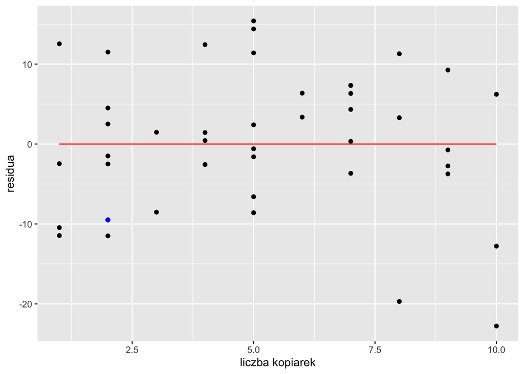

```r
# b)
res_graph(copy_machines_1, model_copy_1)
```

W residua nie układają się w żaden wzór i nie skupiają się w jednej określonej wartości.

### (c)

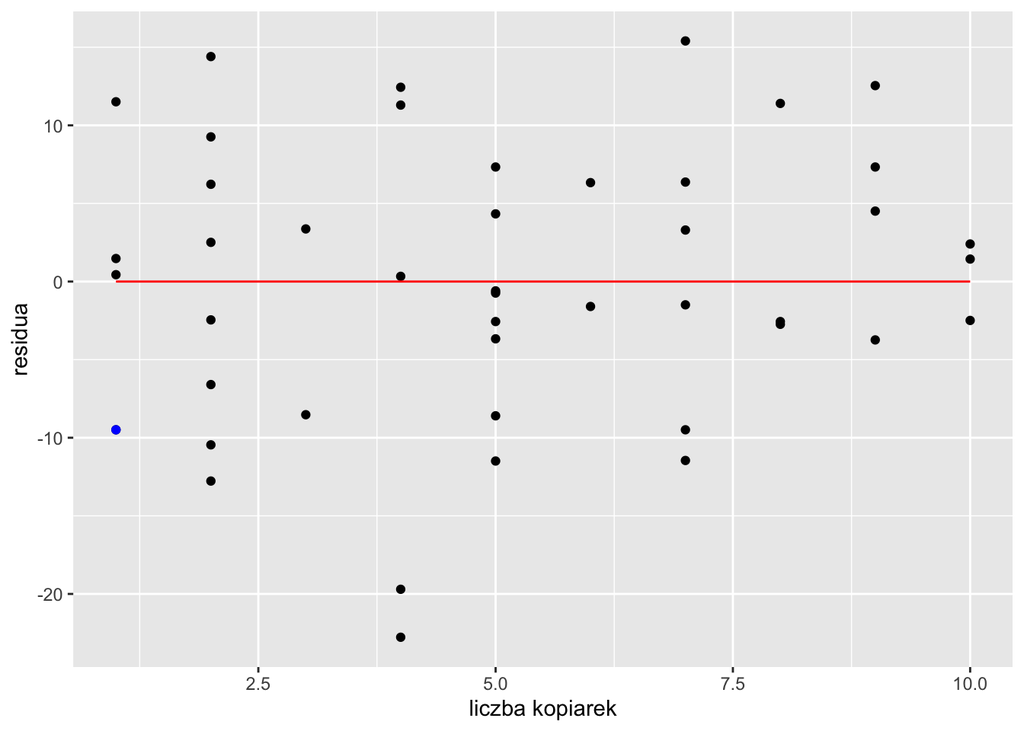

```r
# c)

res_graph(copy_machines_1, model_copy_1, sorting = TRUE)
```

Tak samo jak w (b), nie zauważamy nic niezwykłego.

### (d)

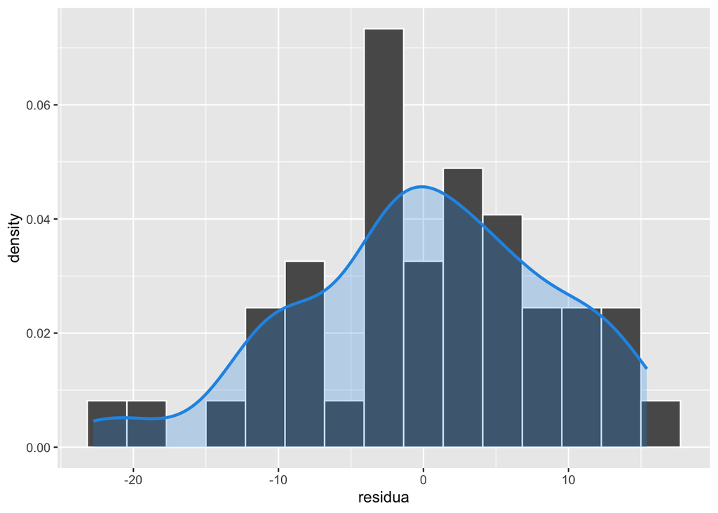

```r
normal_dist(model_copy_1)
```

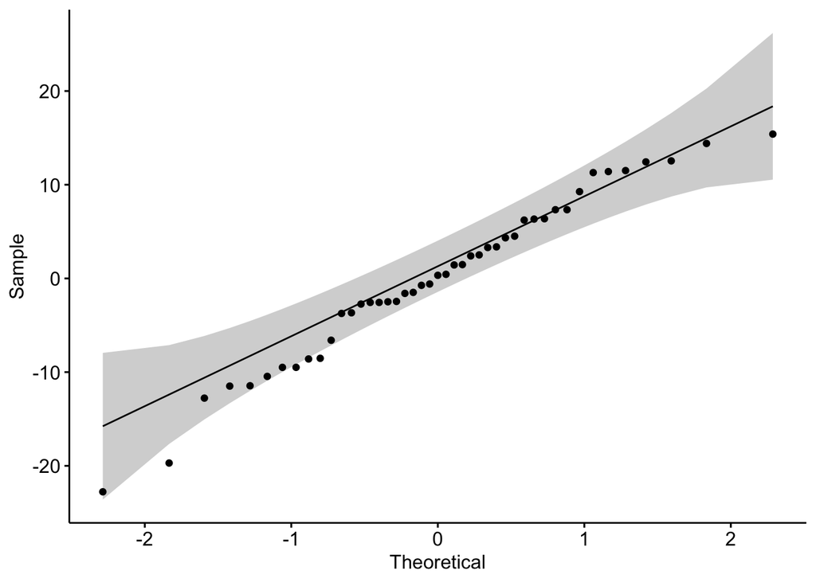

```r
res_copy_1 <- model_copy_1$residuals

ggqqplot(res_copy_1)
```

```r
shapiro.test(res_copy_1)
```

```
##
##  Shapiro-Wilk normality test
##
## data:  res_copy_1
## W = 0.97583, p-value = 0.4614
```

Po przeprowadzeniu testu Shapiro-Wilka, do sprawdzenia normalności rozkładu, nie ma przesłanek do odrzucenia hipotezy zerowej - reszty są z rozkładu normalnego, dlatego zastosowanie regresji liniowej jest tutaj w pełni zrozumiałe i trafne. Wykres kwantylowo kwantylowy również wygląda zadowalająco. Na histogramie nie wygląda to aż tak dobrze, ale może być to spowodowane złym naniesieniem danych, bardziej przypomina rozkład t-studenta.

## Zadanie 6

### (a)

```r
model_copy_2 <- model(copy_machines_2, 2, 1)

sum(model_copy_2$residuals)
```

```
## [1] -1.236344e-12
```

```r
summary_copy_1 <- summary_of_model(model_copy_1)
summary_copy_2 <- summary_of_model(model_copy_2)

comparison_2 <- cbind(summary_copy_1,
                    c(" ", " ", "    > ", "    > ", "    < ", "    < ", "  >"),
                    summary_copy_2)
colnames(comparison_2) <- c("model 1", " ", "model 2" )
comparison_2
```

|  | model 1 |  | model 2 |
| --- | --- | --- | --- |
| wyraz wolny | -0.5802 |  | 135.9003 |
| wsp. kierunkowy | 15.0352 |  | -3.0587 |
| R2 | 0.9575 | > | 0.0009 |
| wartość statystyki t | 31.1233 | > | -0.1927 |
| p-wartość | 0.0000 | < | 0.8481 |
| sigma2 | 79.4506 | < | 85759.4331 |
| wartość F | 968.6572 | > | 0.0371 |

### (b)

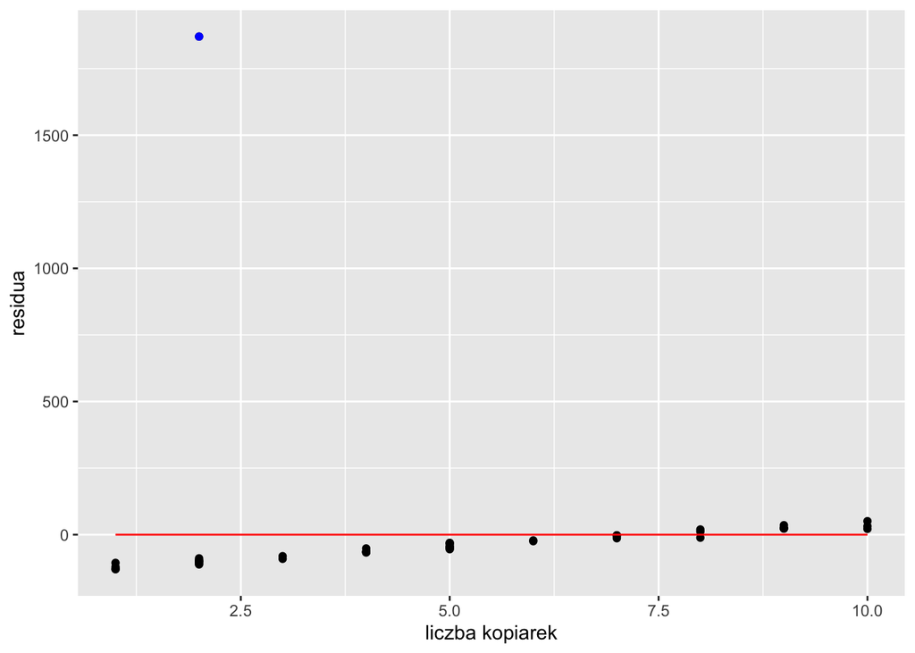

```r
# b)

res_graph(copy_machines_2, model_copy_2)
```

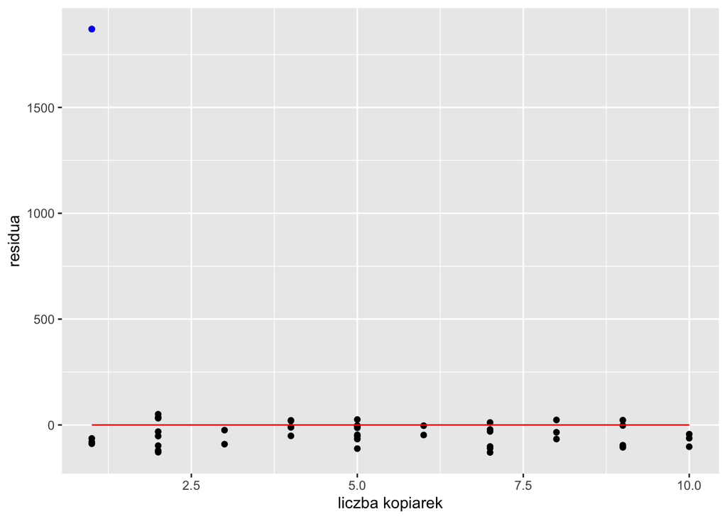

```r
res_graph(copy_machines_2, model_copy_2, sorting = TRUE)
```

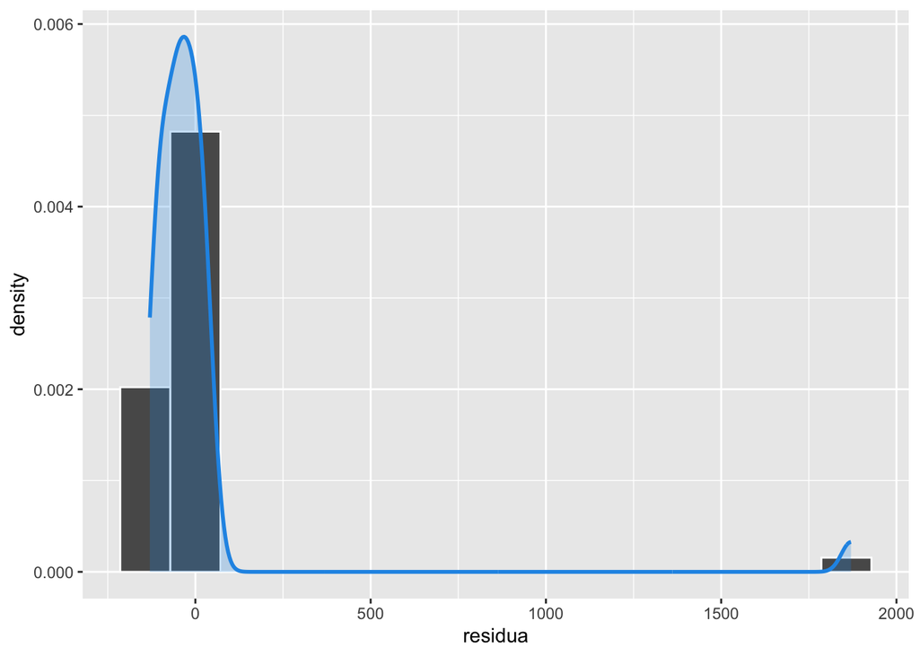

```r
normal_dist(model_copy_2)
```

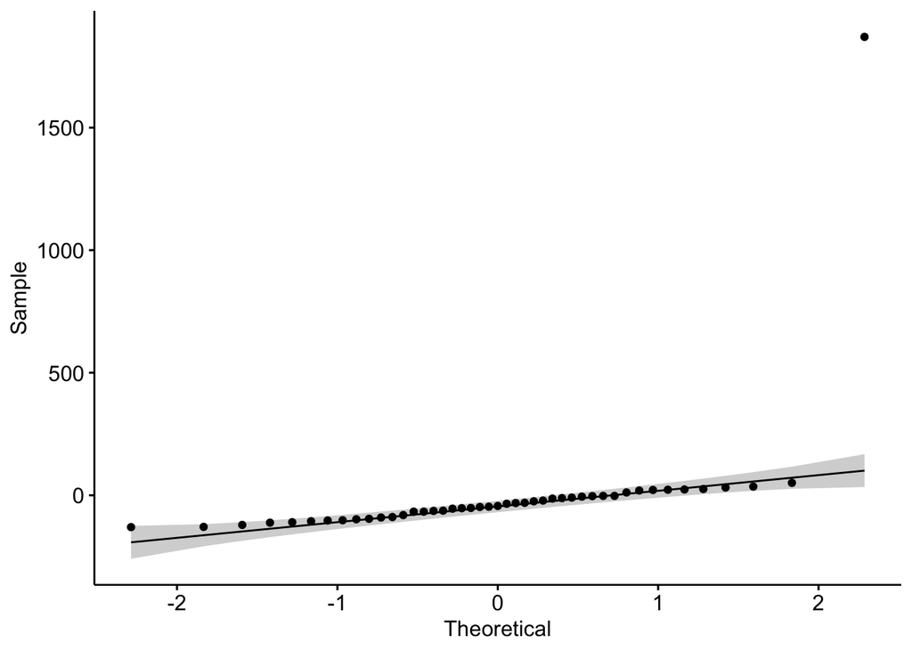

```r
res_copy_2 <- model_copy_2$residuals

ggqqplot(res_copy_2)
```

```r
shapiro.test(res_copy_2)
```

```
##
##  Shapiro-Wilk normality test
##
## data:  res_copy_2
## W = 0.27107, p-value = 1.276e-13
```

Po obejrzeniu wykresów wnioskujemy, że nawet jeden punkt znacząco odstający od pozostałych, tak bardzo psuje nasz model, że nie możemy wnioskować na ich podstawie. Hipotezy, które normalnie byśmy odrzucili przyjmujemy i na odwrót. Model regresji liniowej jest wrażliwy na punkty odstające.

## Zadanie 7

```r
model_concentration   <- model(data_for_model = solution_concentration, 2, 1)
summary_concentration <- summary_of_model(model_name = model_concentration)
summary_concentration
```

|  | wyniki |
| --- | --- |
| wyraz wolny | 2.5753 |
| wsp. kierunkowy | -0.3240 |
| R2 | 0.8116 |
| wartość statystyki t | -7.4829 |
| p-wartość | 0.0000 |
| sigma2 | 0.2250 |
| wartość F | 55.9938 |

Dla statystyki t odrzucamy hipotezę zerową, która mówi o tym, że dane nie zależą od zmiennaj objaśniającej. Model jest całkiem dobrze dopasowany do danych.

## Zadanie 8

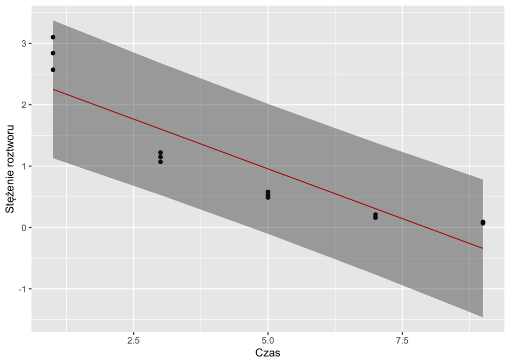

```r
graph_pred(solution_concentration, model_concentration, 2, 1,
           "Czas", "Stężenie roztworu" )
```

```r
cor(solution_concentration$concentration, model_concentration$fitted.values)
```

```
## [1] 0.9008759
```

Nasz model nie wygląda tak źle. Jednak możemy zauważyć, że da się go lepiej dopasować, ze względu na kształt w jaki się układają wyniki.

## Zadanie 9

Transformacja Boxa–Coxa umożliwia wybór optymalnego przekształcenia, takiego by między danymi zachodziła zależność liniowa. W R wygląda to następująco.

```r
box_cox_model_1 <- boxcox(lm(model_concentration))
```

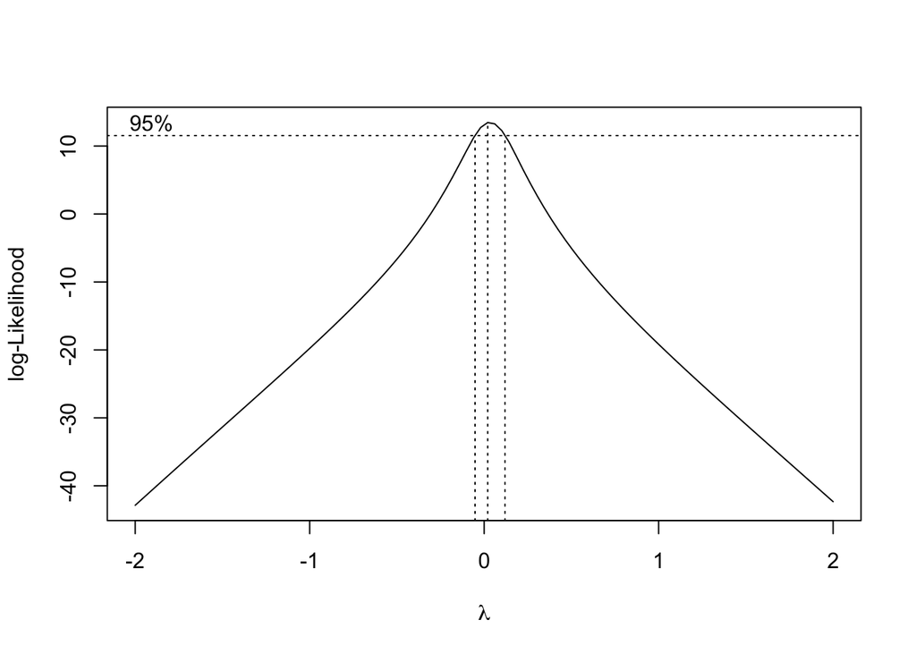

```r
box_cox_model_1$x[which.max(box_cox_model_1$y)]
```

```
## [1] 0.02020202
```

Innym sposobem jest wyliczenie ręczne:

$$f_\lambda(x) =
\begin{cases}
\frac{x^\lambda -1}{\lambda} \text{ }\text{ }\text{ }\text{ }\text{
}\text{ for }\lambda\neq 0 \\
\log(x)\text{}\text{}\text{ }\text{ }\text{ }\text{ for }\lambda = 0
\end{cases}.$$

## Zadanie 10

Gdy już naniesiemy poprawki na dane, to możemy ponownie spróbować dopasować nowy model.

```r
log_model_concentration <-  model(log_solution_concentration, 2, 1)
log_summary_concentration <- summary_of_model(log_model_concentration)
log_summary_concentration
```

|  | wyniki |
| --- | --- |
| wyraz wolny | 1.5079 |
| wsp. kierunkowy | -0.4499 |
| R2 | 0.9930 |
| wartość statystyki t | -42.8745 |
| p-wartość | 0.0000 |
| sigma2 | 0.0132 |
| wartość F | 1838.2250 |

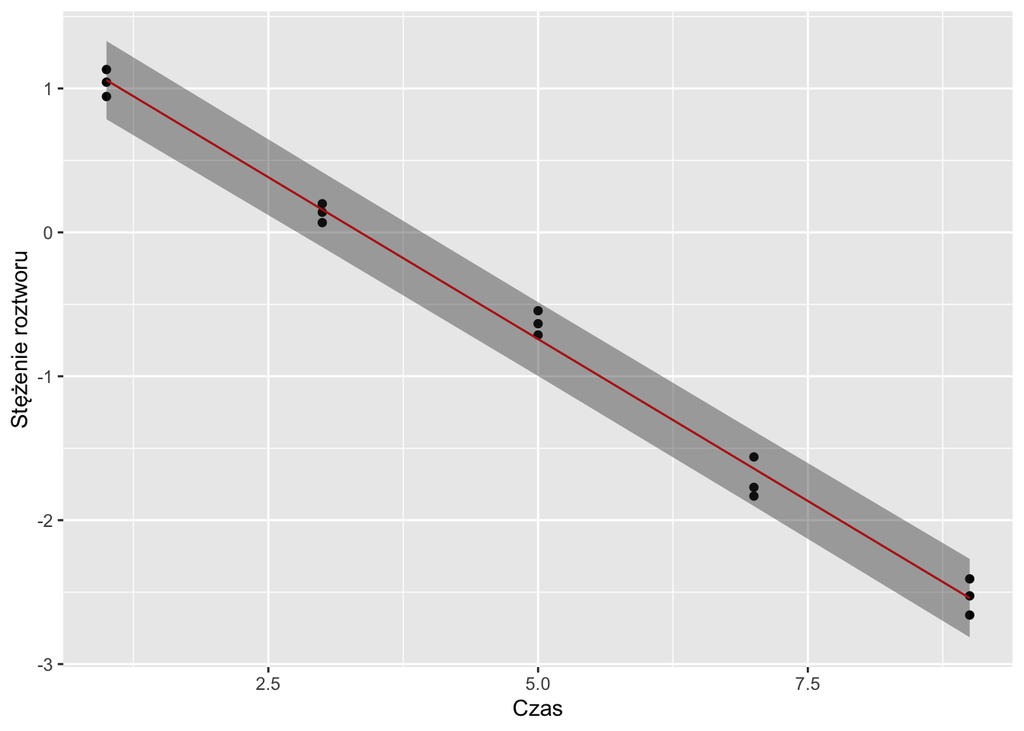

```r
graph_pred(log_solution_concentration, log_model_concentration, 2, 1,
           "Czas", "Stężenie roztworu" )
```

```r
cor(log_solution_concentration$concentration,
    log_model_concentration$fitted.values)
```

```
## [1] 0.9964826
```

Jak widać jest on dopasowany prawie idealnie.

## Zadanie 11

Gdy już mamy dobrze dopasowany model przydałoby się wrócić z danymi do pierwotnej postaci. W tym celu zastosujemy przekształcenie odwrotne.

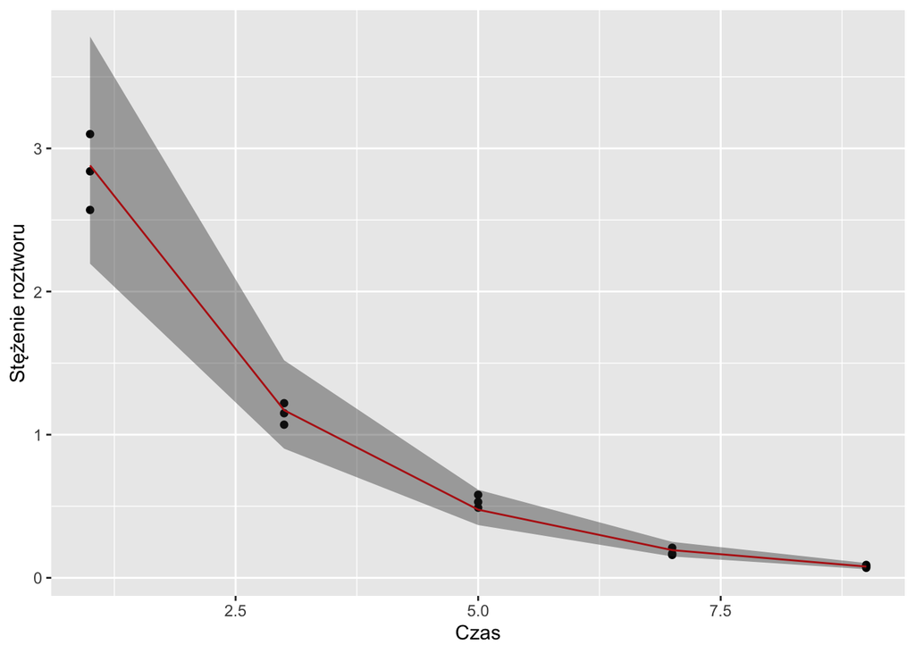

```r
new_fit <- graph_pred(log_solution_concentration, log_model_concentration, 2, 1,
           "Czas", "Stężenie roztworu", typ = FALSE )

new_fit <- cbind(exp(new_fit$concentration), new_fit$time, exp(new_fit[, 3:5]))
colnames(new_fit) <- c("concentration", "time", "fit", "lwr", "upr")

ggplot(new_fit, aes(x = new_fit$time, y = new_fit$concentration)) +
  geom_point() +
  geom_line(aes(x = new_fit$time, y = fit), col = "red") +
  geom_ribbon(aes(ymin = lwr, ymax = upr), alpha = 0.4) +
  xlab("Czas") + ylab("Stężenie roztworu")
```

```r
cor(solution_concentration$concentration,
    exp(log_model_concentration$fitted.values))
```

```
## [1] 0.9945587
```

Tak oto prezentują się nasze dane z dobrze dopasowanym do nich modelem.

## Zadanie 12

Zadanie 12 jest powtórką z 4 ostatnich zadań. W pierwszej kolejności próbujemy dopasować model na dane, które jeszcze nie są przekształcone, następnie podmieniamy wartości zmiennej objaśniającej i jeszcze raz próbujemy dopasować model. Gdy udaje się, wracamy z danymi.

```r
  sqrt_model_concentration <-  model(sqrt_solution_concentration, 2, 1)
  sqrt_summary_concentration <- summary_of_model(sqrt_model_concentration)
  sqrt_summary_concentration
```

|  | wyniki |
| --- | --- |
| wyraz wolny | -1.3408 |
| wsp. kierunkowy | 4.1963 |
| R2 | 0.9881 |
| wartość statystyki t | 32.8032 |
| p-wartość | 0.0000 |
| sigma2 | 0.0143 |
| wartość F | 1076.0501 |

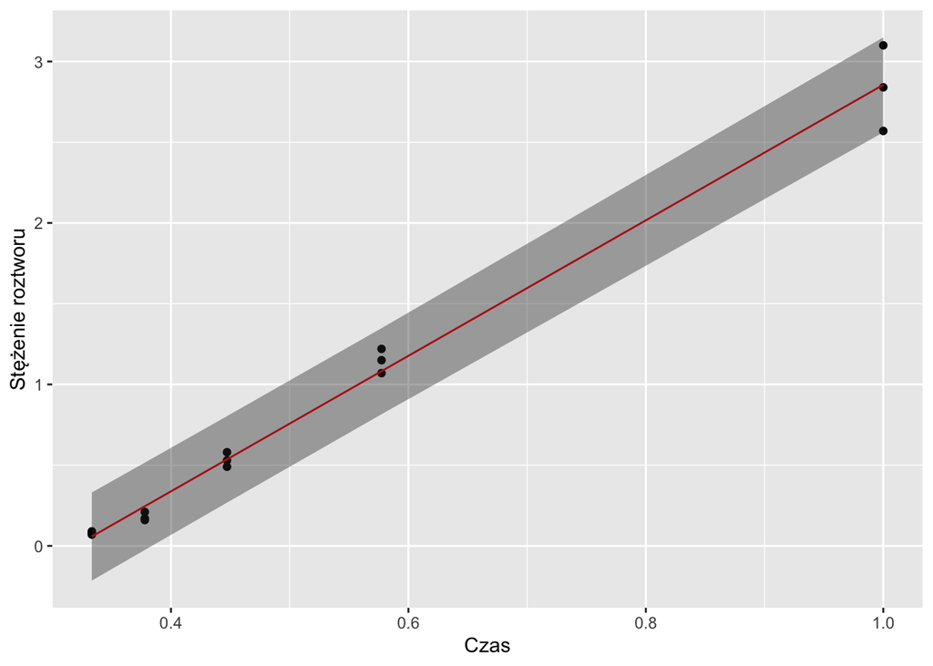

```r
  graph_pred(sqrt_solution_concentration, sqrt_model_concentration, 2, 1,
             "Czas", "Stężenie roztworu" )
```

```r
  cor(sqrt_solution_concentration$concentration,
      sqrt_model_concentration$fitted.values)
```

```
## [1] 0.9940136
```

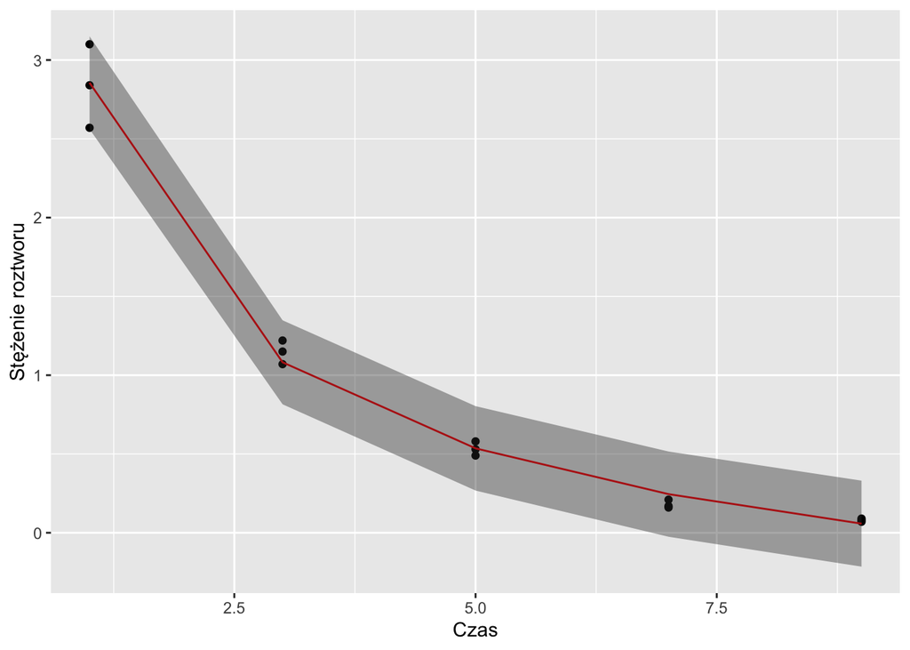

```r
  new_fit_2 <- graph_pred(sqrt_solution_concentration, sqrt_model_concentration, 2, 1,
                        "Czas", "Stężenie roztworu", typ = FALSE )

  new_fit_2 <- cbind((new_fit_2$concentration), 1/new_fit_2$time^2, (new_fit_2[, 3:5]))
  colnames(new_fit_2) <- c("concentration", "time", "fit", "lwr", "upr")

  ggplot(new_fit_2, aes(x = new_fit_2$time, y = new_fit_2$concentration)) +
    geom_point() +
    geom_line(aes(x = new_fit_2$time, y = fit), col = "red") +
    geom_ribbon(aes(ymin = lwr, ymax = upr), alpha = 0.4) +
    xlab("Czas") + ylab("Stężenie roztworu")
```

```r
  cor(solution_concentration$concentration,
      (new_fit_2$fit))
```

```
## [1] 0.9940136
```